# dacon_carprice_upload_20231220

### 분석 개요

[figure not shown]

```python
from IPython.display import clear_output
from IPython.display import Image
Image('자동차가격.jpg')
```

본 분석에서는 성능평가를 위해서 대회용 학습데이터(train.csv)를 다시 분할(train,test)하여 진행한다.

#### 변수 설명

ID : 샘플 별 고유 id  
생산년도 : 차량이 생산된 연도  
모델출시년도 : 차량의 모델이 처음으로 출시된 연도  
브랜드  
차량모델명  
판매도시 : 3글자로 인코딩된 도시 이름  
판매구역 : 3글자로 인코딩된 구역 이름  
주행거리 : 총 주행 거리(km)  
배기량 : 내연기관에서 피스톤이 최대로 밀어내거나 빨아들이는 부피 (cc)  
압축천연가스(CNG) : 압축천연가스(CNG) 자동차 여부  
경유 : 경유 자동차 여부  
가솔린 : 가솔린 자동차 여부  
하이브리드 : 하이브리드 자동차 여부  
액화석유가스(LPG) : 액화석유가스(LPG) 자동차 여부  
가격 : 자동차 가격(백만원)

#### 분석 Keypoint

```python
import pandas as pd
import numpy as np
import janitor
```

```python
import warnings
warnings.filterwarnings(action='ignore')
```

```python
pd.options.display.float_format = '{:.5f}'.format
```

```python
dat = pd.read_csv('./open/train.csv')
```

```python
#dat = dat.clean_names()
```

```python
dat.info()
```

```
<class 'pandas.core.frame.DataFrame'>
RangeIndex: 57920 entries, 0 to 57919
Data columns (total 15 columns):
 #   Column       Non-Null Count  Dtype
---  ------       --------------  -----
 0   ID           57920 non-null  object
 1   생산년도         57920 non-null  int64
 2   모델출시년도       57920 non-null  int64
 3   브랜드          57920 non-null  object
 4   차량모델명        57920 non-null  object
 5   판매도시         57920 non-null  object
 6   판매구역         57920 non-null  object
 7   주행거리         57920 non-null  int64
 8   배기량          57920 non-null  int64
 9   압축천연가스(CNG)  57920 non-null  int64
 10  경유           57920 non-null  int64
 11  가솔린          57920 non-null  int64
 12  하이브리드        57920 non-null  int64
 13  액화석유가스(LPG)  57920 non-null  int64
 14  가격           57920 non-null  float64
dtypes: float64(1), int64(9), object(5)
memory usage: 6.6+ MB
```

### 전처리 ===========================================

#### 결측치 확인

```python
dat.isnull().sum()
```

```
ID             0
생산년도           0
모델출시년도         0
브랜드            0
차량모델명          0
판매도시           0
판매구역           0
주행거리           0
배기량            0
압축천연가스(CNG)    0
경유             0
가솔린            0
하이브리드          0
액화석유가스(LPG)    0
가격             0
dtype: int64
```

결측없음

```python
dat = dat.drop(['ID'], axis = 1)
```

```python
dat.columns
```

```
Index(['생산년도', '모델출시년도', '브랜드', '차량모델명', '판매도시', '판매구역', '주행거리', '배기량',
       '압축천연가스(CNG)', '경유', '가솔린', '하이브리드', '액화석유가스(LPG)', '가격'],
      dtype='object')
```

```python
dat.columns = ['p_year','n_year','brand','model_name','sell_city','sell_block','drive_dist','cc','CNG','diesel','gasoline','hybrid','LNG','price']
```

```python
dat1 = pd.concat([dat,pd.DataFrame({'fuel': np.repeat('없음',len(dat)).tolist()})],axis=1)
```

```python
dat1.head()
```

|  | p_year | n_year | brand | model_name | sell_city | sell_block | drive_dist | cc | CNG | diesel | gasoline | hybrid | LNG | price | fuel |
| --- | --- | --- | --- | --- | --- | --- | --- | --- | --- | --- | --- | --- | --- | --- | --- |
| 0 | 2018 | 2014 | skoda | fabia | KAT | SLA | 85231 | 999 | 0 | 0 | 1 | 0 | 0 | 51.74000 | 없음 |
| 1 | 2010 | 2006 | toyota | auris | RKO | SWI | 135000 | 1598 | 0 | 0 | 1 | 0 | 0 | 41.47000 | 없음 |
| 2 | 2002 | 2002 | mercedes-benz | clk-klasa | GNI | WIE | 255223 | 1796 | 0 | 0 | 1 | 0 | 0 | 17.81000 | 없음 |
| 3 | 2006 | 2001 | nissan | x-trail | EHX | WIE | 238000 | 2184 | 0 | 1 | 0 | 0 | 0 | 18.20000 | 없음 |
| 4 | 2007 | 2007 | fiat | bravo | OSW | MAL | 251000 | 1910 | 0 | 1 | 0 | 0 | 0 | 17.55000 | 없음 |

```python
dat1.loc[dat['CNG']==1,'fuel'] = 'CNG'
dat1.loc[dat['diesel']==1,'fuel'] = 'diesel'
dat1.loc[dat['gasoline']==1,'fuel'] = 'gasoline'
dat1.loc[dat['hybrid']==1,'fuel'] = 'hybrid'
dat1.loc[dat['LNG']==1,'fuel'] = 'LNG'
```

```python
dat1 = dat1.drop(['CNG','diesel','gasoline','hybrid','LNG'], axis = 1)
```

### EDA =============================================

```python
dat1.head()
```

|  | p_year | n_year | brand | model_name | sell_city | sell_block | drive_dist | cc | price | fuel |
| --- | --- | --- | --- | --- | --- | --- | --- | --- | --- | --- |
| 0 | 2018 | 2014 | skoda | fabia | KAT | SLA | 85231 | 999 | 51.74000 | gasoline |
| 1 | 2010 | 2006 | toyota | auris | RKO | SWI | 135000 | 1598 | 41.47000 | gasoline |
| 2 | 2002 | 2002 | mercedes-benz | clk-klasa | GNI | WIE | 255223 | 1796 | 17.81000 | gasoline |
| 3 | 2006 | 2001 | nissan | x-trail | EHX | WIE | 238000 | 2184 | 18.20000 | diesel |
| 4 | 2007 | 2007 | fiat | bravo | OSW | MAL | 251000 | 1910 | 17.55000 | diesel |

```python
import matplotlib.pyplot as plt
import seaborn as sns
```

```python
num_dat = dat1.select_dtypes('number')
```

```python
num_dat.describe()
```

|  | p_year | n_year | drive_dist | cc | price |
| --- | --- | --- | --- | --- | --- |
| count | 57920.00000 | 57920.00000 | 57920.00000 | 57920.00000 | 57920.00000 |
| mean | 2011.35535 | 2008.03341 | 167869.08840 | 1788.16013 | 52.21175 |
| std | 5.17411 | 5.08796 | 83191.19616 | 545.41382 | 35.39972 |
| min | 1978.00000 | 1983.00000 | 1.00000 | 875.00000 | 1.17000 |
| 25% | 2008.00000 | 2004.00000 | 111434.50000 | 1461.00000 | 24.57000 |
| 50% | 2011.00000 | 2008.00000 | 171000.00000 | 1753.00000 | 42.25000 |
| 75% | 2016.00000 | 2012.00000 | 220000.00000 | 1995.00000 | 73.97000 |
| max | 2022.00000 | 2021.00000 | 2500000.00000 | 6300.00000 | 156.00000 |

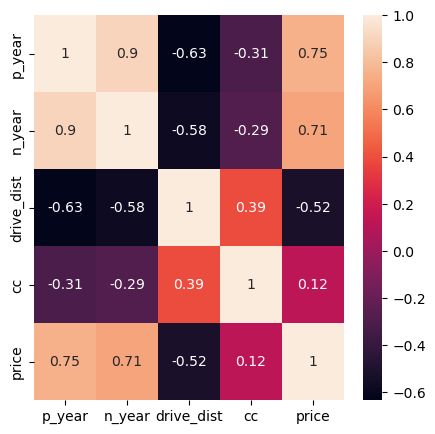

```python
plt.figure(figsize=(5,5))
corr = num_dat.corr()
sns.heatmap(corr, annot = True)
plt.show();
```

#### 수치형 변수 히스토그램

```python
num_dat.columns
```

```
Index(['p_year', 'n_year', 'drive_dist', 'cc', 'price'], dtype='object')
```

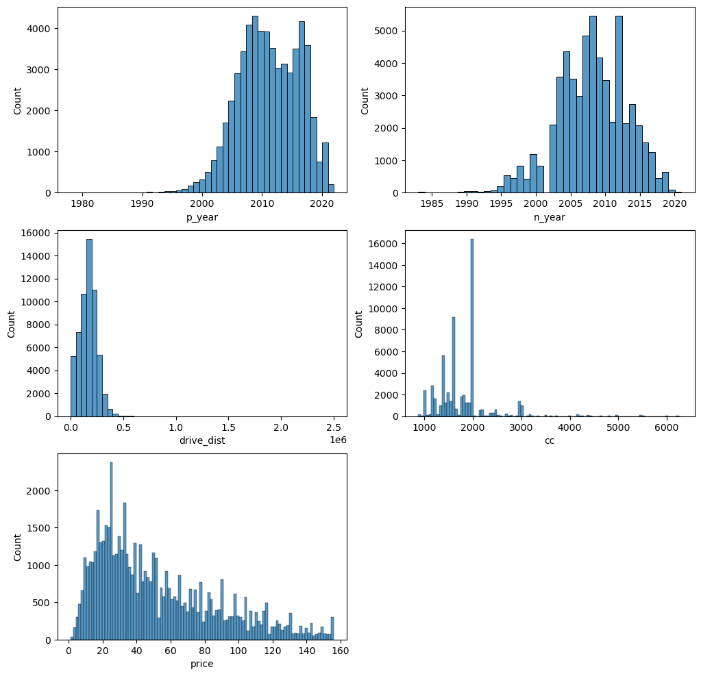

```python
fig = plt.figure(figsize=(12,12))
ax1 = fig.add_subplot(3,2,1)
ax2 = fig.add_subplot(3,2,2)
ax3 = fig.add_subplot(3,2,3)
ax4 = fig.add_subplot(3,2,4)
ax5 = fig.add_subplot(3,2,5)

sns.histplot(x=num_dat['p_year'], bins=45, ax=ax1)
sns.histplot(x=num_dat['n_year'], bins=40, ax=ax2)
sns.histplot(x=num_dat['drive_dist'], bins=50, ax=ax3)
sns.histplot(x=num_dat['cc'], bins=100, ax=ax4)
sns.histplot(x=num_dat['price'], bins=100, ax=ax5)
plt.show()
```

#### 수치형 변수 BOXPLOT

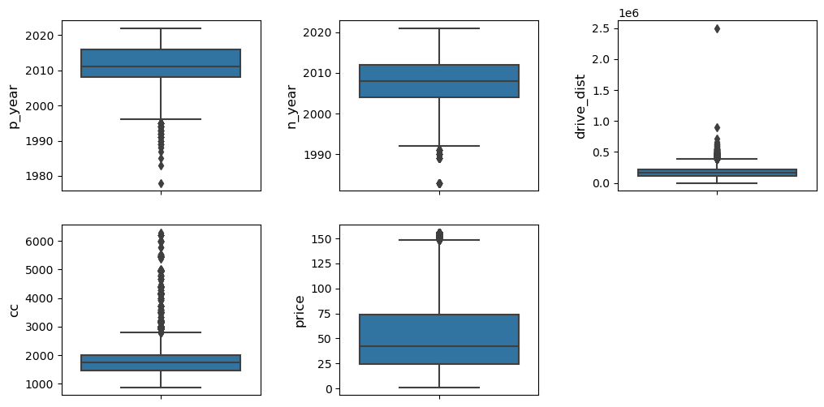

```python
gname = num_dat.columns.tolist()

fig = plt.figure(figsize=(12,6))  # 전체 그래프 크기
plt.subplots_adjust(wspace=0.4, hspace=0.2) # 그래프 간 간격
for i in range(len(gname)) :
    plt.rc('axes', labelsize=12)   # x,y축 label 폰트 크기
    plt.rc('xtick', labelsize=10)  # x축 눈금 폰트 크기
    plt.rc('ytick', labelsize=10)  # y축 눈금 폰트 크기
    ax1 = fig.add_subplot(2,3,(i+1))
    sns.boxplot(y=num_dat[gname[i]], ax=ax1)
    plt.xticks()
plt.show()
```

생산년도, 주행거리, 배기량에서 이상치가 보인다.생산년도, 배기량의 이상치는 가능한 수치이다.  
주행거리의 경우 현실적으로 너무 큰 차이가 남으로 1.0이상은 삭제한다.

#### 수치형 변수 이상치 개수 및 비율 확인

```python
def find_out(num_dat):
    gname = num_dat.columns.tolist()
    for i in range(len(gname)) :
            Q1 = np.quantile(num_dat[gname[i]], 0.25)# 1
            Q3 = np.quantile(num_dat[gname[i]], 0.75)# 3
            IQR = Q3 - Q1
            UC = Q3 + (1.5 * IQR)
            LC = Q3 - (1.5 * IQR)
            isdf = num_dat.loc[(num_dat[gname[i]] > UC) | (num_dat[gname[i]] < LC), :]
            print(gname[i]," : ",round(len(isdf)/len(dat1),4))
```

```python
find_out(num_dat)
```

```
p_year  :  0.0605
n_year  :  0.0481
drive_dist  :  0.1125
cc  :  0.1195
price  :  0.0122
```

#### 주행거리 이상치 처리

주행거리 1,000,000이상은 삭제

```python
dat1.drive_dist.describe()
```

```
count     57920.00000
mean     167869.08840
std       83191.19616
min           1.00000
25%      111434.50000
50%      171000.00000
75%      220000.00000
max     2500000.00000
Name: drive_dist, dtype: float64
```

```python
dat2 = dat1.loc[dat1['drive_dist']<1000000,:]
```

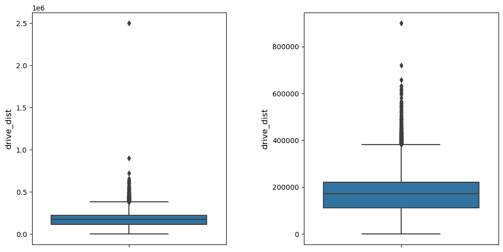

```python
fig = plt.figure(figsize=(12,6))  # 전체 그래프 크기
plt.subplots_adjust(wspace=0.4, hspace=0.2) # 그래프 간 간격

ax1 = fig.add_subplot(1,2,1)
ax2 = fig.add_subplot(1,2,2)
sns.boxplot(y=dat1['drive_dist'],ax=ax1)
sns.boxplot(y=dat2['drive_dist'],ax=ax2)
plt.show()
```

### FEATURE ENGINEERING ============================

#### 배기량 500단위로 범주화

```python
dat2.cc.describe()
```

```
count   57919.00000
mean     1788.15649
std       545.41782
min       875.00000
25%      1461.00000
50%      1753.00000
75%      1995.00000
max      6300.00000
Name: cc, dtype: float64
```

```python
bin_dividers =[0,1000,1500,2000,2500,3000,3500,4000,4500,5000,5500,6000,7000]
```

```python
bin_names = ["1000미만","1000_1499","1500_1999","2000_2499","2500_2999","3000_3499","3500_3999","4000_4499","4500_4999","5000_5499","5500_5999","6000이상"]
```

```python
dat2['cc_1'] = pd.cut(x=dat2['cc'],     # 데이터 배열
                      bins=bin_dividers,      # 경계 값 리스트
                      labels=bin_names,       # bin 이름
                      include_lowest=False)    # 첫 경계값 포함
```

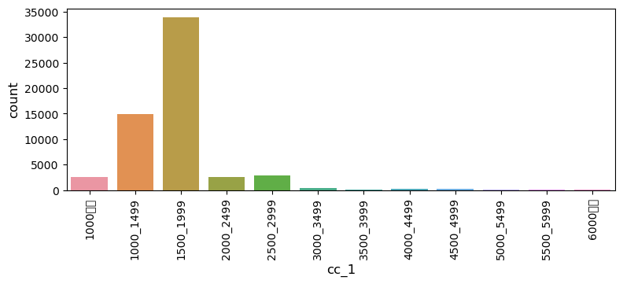

```python
plt.figure(figsize=(9,3))
sns.countplot(dat2['cc_1'])
plt.xticks(rotation=90)
plt.show()
```

#### 주행거리 50000단위로 범주화

```python
dat2.drive_dist.describe()
```

```
count    57919.00000
mean    167828.82301
std      82625.58452
min          1.00000
25%     111433.00000
50%     171000.00000
75%     220000.00000
max     900000.00000
Name: drive_dist, dtype: float64
```

```python
bin_dividers =[0,50000,100000,150000,200000,250000,300000,350000,1000000]
bin_names = ["50000미만","50000_99999","100000_149999","150000_199999","200000_249999","250000_299999","300000_349999","350000이상"]
```

```python
dat2['drive_dist_1'] = pd.cut(x=dat2['drive_dist'],     # 데이터 배열
                      bins=bin_dividers,      # 경계 값 리스트
                      labels=bin_names,       # bin 이름
                      include_lowest=False)    # 첫 경계값 포함
```

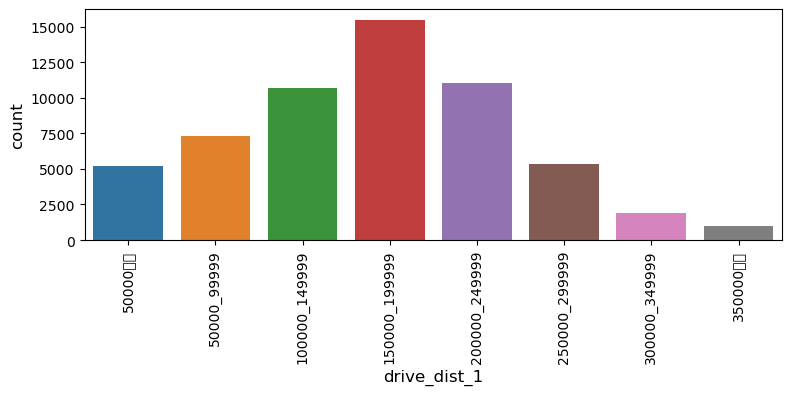

```python
plt.figure(figsize=(9,3))
sns.countplot(dat2['drive_dist_1'])
plt.xticks(rotation=90)
plt.show()
```

#### 주요 변수별 평균 가격 생성

```python
brand_mean = pd.DataFrame({
    'brand':dat2.groupby('brand')['price'].mean().index,
    'brand_mean':dat2.groupby('brand')['price'].mean().values
})
model_name_mean = pd.DataFrame({
    'model_name':dat2.groupby('model_name')['price'].mean().index,
    'model_name_mean':dat2.groupby('model_name')['price'].mean().values
})
sell_city_mean = pd.DataFrame({
    'sell_city':dat2.groupby('sell_city')['price'].mean().index,
    'sell_city_mean':dat2.groupby('sell_city')['price'].mean().values
})
cc_1_mean = pd.DataFrame({
    'cc_1':dat2.groupby('cc_1')['price'].mean().index,
    'cc_1_mean':dat2.groupby('cc_1')['price'].mean().values
})
fuel_mean = pd.DataFrame({
    'fuel':dat2.groupby('fuel')['price'].mean().index,
    'fuel_mean':dat2.groupby('fuel')['price'].mean().values
})
```

```python
dat3 = pd.merge(dat2, brand_mean, how='left', on='brand')
dat3 = pd.merge(dat3, model_name_mean, how='left', on='model_name')
dat3 = pd.merge(dat3, sell_city_mean, how='left', on='sell_city')
dat3 = pd.merge(dat3, cc_1_mean, how='left', on='cc_1')
dat3 = pd.merge(dat3, fuel_mean, how='left', on='fuel')
```

```python
dat3.isna().sum()
```

```
p_year             0
n_year             0
brand              0
model_name         0
sell_city          0
sell_block         0
drive_dist         0
cc                 0
price              0
fuel               0
cc_1               0
drive_dist_1       0
brand_mean         0
model_name_mean    0
sell_city_mean     0
cc_1_mean          0
fuel_mean          0
dtype: int64
```

#### 주요 변수+변수 별 평균 가격 생성

```python
# 브랜드 + 배기량_1 평균가격
brand_cc_price =  pd.DataFrame(dat2.groupby(['brand','cc_1'])['price'].mean())
brand_cc_price = brand_cc_price.rename(columns={'price':'brand_cc_price'})
dat4 = pd.merge(dat3,brand_cc_price, how='left', on=['brand','cc_1'])

# 모델 + 생산년도 평균가격
modelname_pyear_price =  pd.DataFrame(dat2.groupby(['model_name','p_year'])['price'].mean())
modelname_pyear_price = modelname_pyear_price.rename(columns={'price':'modelname_pyear_price'})
dat4 = pd.merge(dat4,modelname_pyear_price, how='left', on=['model_name','p_year'])

# 배기량 + 생산년도 평균가격
cc_pyear_price = pd.DataFrame(dat2.groupby(['cc_1','p_year'])['price'].mean())
cc_pyear_price = cc_pyear_price.rename(columns={'price':'cc_pyear_price'})
dat4 = pd.merge(dat4,cc_pyear_price, how='left', on=['cc_1','p_year'])

# 생산년도 + 주행거리 평균가격
pyear_dist_price = pd.DataFrame(dat2.groupby(['p_year','drive_dist_1'])['price'].mean())
pyear_dist_price = pyear_dist_price.rename(columns={'price':'pyear_dist_price'})
dat4 = pd.merge(dat4,pyear_dist_price, how='left', on=['p_year','drive_dist_1'])
```

```python
dat4.isna().sum()
```

```
p_year                   0
n_year                   0
brand                    0
model_name               0
sell_city                0
sell_block               0
drive_dist               0
cc                       0
price                    0
fuel                     0
cc_1                     0
drive_dist_1             0
brand_mean               0
model_name_mean          0
sell_city_mean           0
cc_1_mean                0
fuel_mean                0
brand_cc_price           0
modelname_pyear_price    0
cc_pyear_price           0
pyear_dist_price         0
dtype: int64
```

#### 최종변수 선택

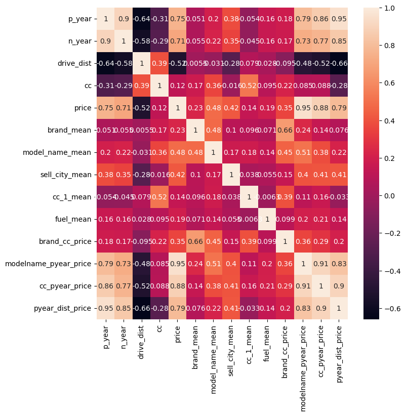

```python
plt.figure(figsize=(8,8))
corr = dat4.select_dtypes('number').corr()
sns.heatmap(corr, annot = True)
plt.show();
```

```python
dat5 = dat4.loc[:,['price','p_year','n_year','drive_dist','cc',
                   'brand_mean','model_name_mean','sell_city_mean','cc_1_mean',
                   'brand_cc_price','modelname_pyear_price','cc_pyear_price',
                   'pyear_dist_price']]
```

### 머신러닝 =========================================

데이터 분할

```python
from sklearn.model_selection import train_test_split
```

```python
y = dat5.price
X = dat5.drop(['price'], axis = 1)
```

```python
y.info()
```

```
<class 'pandas.core.series.Series'>
Int64Index: 57919 entries, 0 to 57918
Series name: price
Non-Null Count  Dtype
--------------  -----
57919 non-null  float64
dtypes: float64(1)
memory usage: 905.0 KB
```

```python
X_train, X_test, y_train, y_test = train_test_split(X, y, test_size=0.2, random_state=123) # 훈련 80 : 테스트 20 으로 분리
```

반응변수 박스콕스 변환

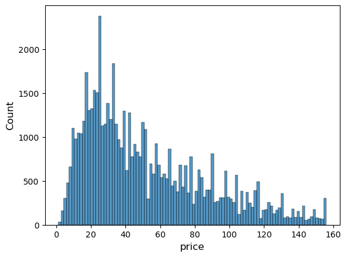

```python
sns.histplot(x=num_dat['price'], bins=100)
plt.show()
```

price의 분포가 오른쪽긴꼬리 형태이다.  
반응변수 박스콕스 변환 필요

```python
from sklearn.preprocessing import PowerTransformer
```

```python
y_train_df = pd.DataFrame(y_train.values, columns=['price'])
```

```python
pt = PowerTransformer(method = 'box-cox')
y_train_df['price'] = pt.fit_transform(y_train_df[['price']])
y_train0  = y_train_df.price
y_train0.index = y_train.index
y_train = y_train0
```

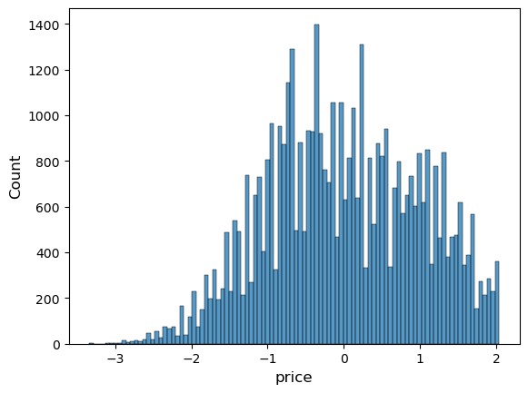

```python
sns.histplot(x=y_train_df['price'], bins=100)
plt.show()
```

#### LGBM

```python
from sklearn.model_selection import GridSearchCV, KFold
from sklearn.model_selection import cross_val_score
```

```python
from lightgbm import LGBMRegressor
```

```python
lgb = LGBMRegressor()
```

```python
lgb_param = {'n_estimators':[200, 500, 1000, 5000],
             'learning_rate' : [0.01, 0.025, 0.05],
             'num_leaves': [3, 4, 5],
             'min_child_samples' : [40, 60],
             'subsample' : [ 0.6, 0.8 ],
            'lambda_l2' : [0 , 10 , 20 , 30 , 50]
            }
```

```python
cv = KFold(n_splits = 5, shuffle = True, random_state = 0)
import os
cpu = os.cpu_count()-2
```

```python
lgb_search = GridSearchCV(estimator = lgb,
param_grid = lgb_param,
cv = cv,
n_jobs=cpu,
scoring = 'neg_mean_squared_error')
```

```python
from pytictoc import TicToc
time = TicToc()
time.tic()
lgb_search.fit(X_train, y_train)
time.toc()
```

```
[LightGBM] [Warning] lambda_l2 is set=0, reg_lambda=0.0 will be ignored. Current value: lambda_l2=0
[LightGBM] [Warning] lambda_l2 is set=0, reg_lambda=0.0 will be ignored. Current value: lambda_l2=0
[LightGBM] [Info] Auto-choosing col-wise multi-threading, the overhead of testing was 0.000925 seconds.
You can set `force_col_wise=true` to remove the overhead.
[LightGBM] [Info] Total Bins 1690
[LightGBM] [Info] Number of data points in the train set: 46335, number of used features: 12
[LightGBM] [Info] Start training from score 0.000000
Elapsed time is 1635.649860 seconds.
```

#### 예측 및 성능평가

```python
pred0 = lgb_search.predict(X_test)
pred0 = pt.inverse_transform(pred0.reshape(-1,1))#박스콕스 역변환
pred = pd.Series(pred0.flatten())
pred.index = y_test.index
```

```
[LightGBM] [Warning] lambda_l2 is set=0, reg_lambda=0.0 will be ignored. Current value: lambda_l2=0
```

```python
from sklearn.metrics import r2_score, mean_absolute_error, mean_squared_error
```

```python
#RMSE
np.sqrt(mean_squared_error(y_test,pred))
```

```
8.707323260567252
```

```python
#MAE
mean_absolute_error(y_test,pred)
```

```
5.716731827109088
```